# Dæmaverkefni 1: Fyrstu skrefin í R

Markmiðið í þessari viku er að kynna ykkur fyrir R og RStudio og gefa ykkur tækifæri á að spreyta ykkur sjálf á því að skrifa kóða. Við förum í algjör grunnatriði að þessu sinni: að búa til og vista skrár, nota einfaldar skipanir og kíkja aðeins á gögn.

# 1 R Markdown skjöl

## 1.1 Að búa til nýtt skjal

Þegar við búum til skjal sem inniheldur texta þá notum við alla jafna Word og vistum skjal af gerðinni “.docx”. Í R notum við aðallega skráartegund sem heitir R Markdown og vistum skjal af gerðinni “.Rmd”. R Markdown skjöl eru gagnleg þar sem þau gera okkur kleift að vefa saman texta og kóða í einu skjali og hafa þannig alla vinnuna okkar saman á einum stað. Við vistum skjalið undir “.Rmd” endingunni, en við getum líka vefað það (e. knit) og búið til aðrar skráartegundir (html, word, pdf, og glærur) sem við getum svo dreift áfram til annarra.

Til að búa til nýja skrá skaltu smella á græna plúsinn upp í vinstra horninu á RStudio og velja R Markdown. Á glugganum sem sprettur upp er nóg að smella á OK. (Það er líka hægt að nota valmyndina efst og fara í “File > New File > R Markdown…”)

Þegar þú býrð til R Markdown skjal þá inniheldur skjalið alltaf sýnitexta og -kóða, sem við viljum losna við. Nánar um það næst.

## 1.2 Að breyta skjali

Byrjaðu á því að að breyta R Markdown skjalinu sem þú varst að búa til. Hafðu myndina að neðan til hliðsjónar.

1. Breyttu titlinum á skjalinu í “Dæmaverkefni 1 í STJ208G”. Passaðu að fjarlægja ekki gæsalappirnar.
2. Settu inn nafnið þitt og dagsetninguna á skilaverkefninu í línurnar tvær fyrir neðan. Passaðu upp á gæsalappirnar!
3. Eyddu öllu fyrir neðan línu 6 í skjalinu.
4. Bættu við fyrirsögnum og texta **nákvæmlega** eins og á myndinni að neðan. Í svarliðum við spurningum skaltu passa að hafa auða línu fyrir ofan og neðan hvern lið og að draga inn textann með því að setja eitt “tab” á undan hverjum lið.
5. Að lokum skaltu setja inn fyrsta kóðabútinn þinn. Byrjaðu á þvi að staðsetja blikkandi strikið í línuna sem þú vilt setja inn kóðabútinn. Það er nokkrar leiðir sem hægt er að fara til að setja inn bútinn, en það er meðal annars hægt að gera með því að velja fara í valmyndina efst efst og velja “Code > Insert Chunk”. Sjálfum finnst mér best að nota lyklaborðið og halda inni CTRL+ALT+I ( Cmd+Option+I í Mac). Þið þurfið sjálf að breyta efstu línunni í kóðabútnum þannig að það standi:
- `{r setup, warning=FALSE, message=FALSE}`

Skjalið ætti að líta svona út þegar hér er komið við sögu:

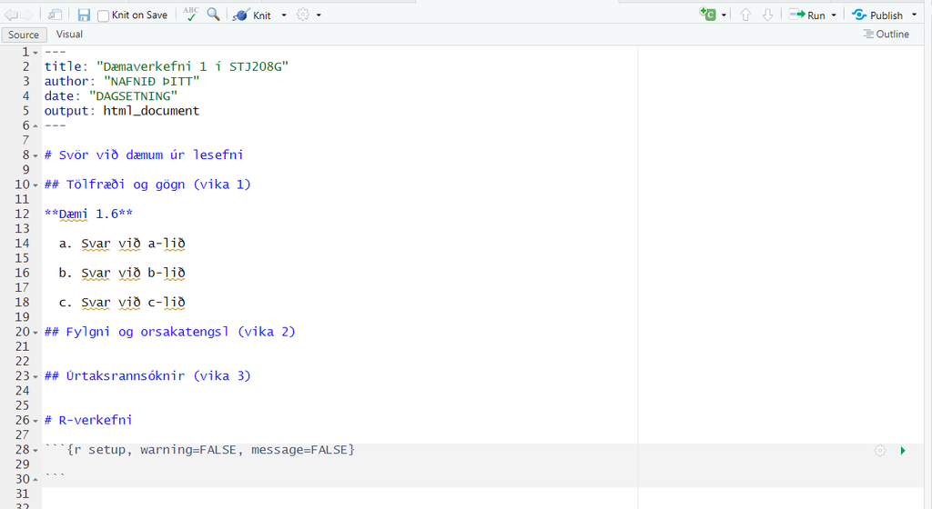

## 1.3 Að vista skjal

Það er til lítils að gera breytingar á skjali ef við ætlum svo ekki að vista það.

Fyrir nemendur sem nota RStudio á eigin tölvu eða í tölvuverinu, þá vil ég minna ykkur á mikilvægi þess að vera mjög skipulögð í því hvernig þið geymið skrár tengdar þessu námskeiði. Hafið þær allar í sömu möppu (og jafnvel undirmöppum, t.d. fyrir hverja æfingu).

Þið öll ættuð svo að vera skipulögð í nöfnum sem þið gefið skránum. Ég mæli með því að byrja skráarheiti alltaf á númerinu á vikunni eða verkefninu, því þá raðast skrárnar í rétta röð í möppunni ykkar. Passið svo að nota ekki bil í skráarheiti og forðist að nota íslenska stafi. Sem dæmi, þá gæti þessi skrá heitið “01_daemaverkefni.Rmd”.

## 1.4 Að vefa HTML skjal

Smellið á Knit takkann ofarlega fyrir miðjum skjánum til að “vefa” skránna saman eða með öðrum orðum að setja saman skjalið í lokamynd. Sjálfgefið er að .html skrá sé búin til, vistuð í sömu möppu og .Rmd skráin og með sama nafni.

Ef það sprettur upp gluggi sem segir að það þurfi að setja inn pakka eða uppfæra pakka til að setja saman skjalið, þá samþykkið þið það.

Skoðaðu nú .html skránna til að sjá hvernig skjalið kemur út í lokamynd. Það er góð regla að vefa skjöl saman reglulega þegar þið eruð að vinna það og tryggja að allt komi út eins og þið gerið ráð fyrir.

HTML skjalið ætti að líta svona út:

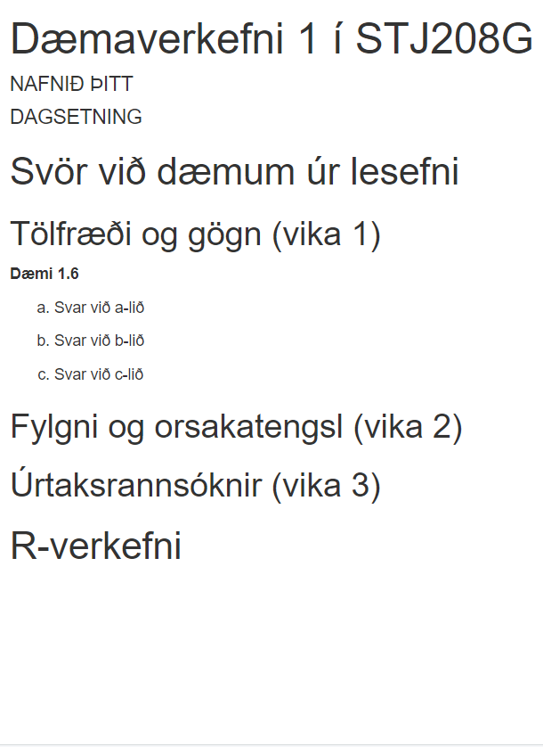

# 2 Dæmaverkefni 1

Nú er komið að ykkur! Dæmaverkefni 1 samanstendur af nokkrum dæmum úr námsefninu sem ég hef sett fyrir í tíma ásamt stuttu R verkefni. Þið skilið svörunum við þessum spurningum og R-verkefninu hér að neðan í html-skjali sem hefur verið vefað saman úr R Markdown skjali. Þið eigið að setja skjalið upp nákvæmlega eins og á myndinni hér að ofan, þar sem fyrirsagnir og undirfyrirsagnir eru notaðar til að aðskilja ólíka hluta verkefnisins. Svörin við spurningunum úr lesefninu eiga svo að fylgja fyrirmyndinni sem ég hef sýnt fyrir dæmi 1.6.

Munið að vista skjalið ykkar reglulega og vefa það saman annað slagið til að þið getið strax lagfært villur sem gætu komið upp.

## 2.1 Dæmi úr lesefni

Dæmin eru flest úr *Introduction to Modern Statistics* og vísa númerin hér að neðan í kaflanúmer og númer dæma í kafla í þeirri bók en auk þess er eitt dæmi úr kafla Kellstedt og Whitten. Dæmin eru eftirfarandi:

**Tölfræði og gögn (vika 1):** 1.6, 1.10, 1.14 og 1.18

**Fylgni og orsakatengsl (vika 2):** 3.7 í Kellstedt og Whitten, 2.12, 2.22 og 2.30 (svara með hliðsjón af orsakahindrunum Kellstedt og Whitten)

**Úrtaksrannsóknir (vika 3):** 2.6, 2.8 og 2.18

## 2.2 R verkefni

Hér að neðan eigið þið að framkvæma nokkrar aðgerðir í R. Kennslumyndböndin á Canvas fara yfir allar aðgerðirnar sem þið eigið að nota, ég mæli því með því að horfa á þau fyrst og vinna ykkur í gegnum R Markdown skjalið með grunnaðgerðunum (grunnadgerdir.Rmd).

1. Byrjið á því hlaða inn nauðsynlegum pökkum fyrir verkefnið. Setjið eftirfarandi skipanir efst í kóðabútinn sem þið eruð nú þegar búin að búa til.

```r
library(knitr)
library(openintro)
```

- Prófið nú að vista skjalið. Ef að þið eruð að nota pakka í fyrsta sinn þá ætti núna að birtast gul lína ofarlega í RStudio þar sem kemur fram að ekki sé búið að sækja pakkann og að þið þurfið að hala honum niður áður en þið notið hann. Líklega eruð þið ekki með pakkann `openintro` á tölvunni ykkar - þið þurfið þá að smella á “Install” á gulu línunni. Athugið að þetta þarf einungis að gera einu sinni (eins og að sækja app í App Store) en í hvert sinn sem við ætlum að nota pakka í skjali þá þarf að byrja á því að vísa til hans með `library()` fallinu (eins og að opna app í síma).
2. Keyrið nú kóðann í R, án þess að vefa skjalið í heild sinni. Ein leið til að gera það er að smella á græna þríhyrninginn efst til hægri á kóðabútnum (eins og play merki). Þegar þið viljið einungis keyra nokkrar línur af kóða (en ekki heilan kóðabút) þá er einfaldast að velja línurnar af kóða sem þið viljið keyra og halda inni CTRL+ENTER (CMD+Return á Mac).
3. Við ætlum aðeins að prófa okkur áfram með `oscars` gagnasettið sem fylgir `openintro` pakkanum, en það inniheldur upplýsingar um einstaklinga sem hafa unnið besti leikari eða besta leikkona á Óskarsverðlaununum. Setjið inn eftirfarandi línu í kóðabútinn til að hlaða pakkanum í minni:

```r
oscars <- oscars
```

- Alla jafna er þetta óþarft, en þar sem við erum að vinna með innbyggt gagnasafn þá þurfum við að hafa þessa skipun með. Munið að keyra línuna jafnóðum með því að smella á græna þríhyrninginn.
4. Þegar þið keyrðuð þessa skipun, hvað birtist í efri glugganum til hægri í RStudio (“Environment”)?
   1. Svarið með texta **fyrir neðan kóðabútinn** og auðkennið svarið með “a.”.
5. Hvað eru mörg tilvik og hvað eru margar breytur í `oscars` gagnarammanum? Þið ættuð að geta séð það uppi í hægra horninu eða með því að keyra skipunina `glimpse(oscars)` í Console glugganum niðri vinstra megin.
   2. Auðkennið svarið með “b.” og setjið fyrir neðan svarið sem var merkt “a.”
6. Prófið nú að vefa saman skjalið og sjá hvernig viðbæturnar ykkar birtast í skjalinu. R hluti verkefnisins ættu núna að líta svona út:

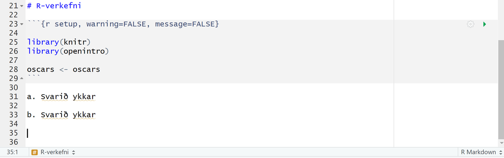

7. Nú skulið þið bæta nokkrum skipunum við kóðabútinn sem gera ykkur kleift að svara eftirfarandi spurningum. Skrifið svo svörin fyrir neðan kóðabútinn. Fyrir hverja spurningu ætti því að vera bæði ein lína af kóða og svo ein lína með svari fyrir utan kóðabútinn. Ég mæli með því að keyra hverja línu og fá þannig svarið með því að halda inni CTRL+Enter (CMD+Return).
   3. Hversu gömul var yngsta manneskjan sem hefur hlotið Óskarsverðlaun fyrir besta leik? Notið breytuna `age` í `oscars` gagnarammanum og `min` fallið til að svara spurningunni. Ef þið eruð ekki viss um hvernig það er gert þá getið þið skoðað hvernig `mean` fallið er notað í skjalinu með grunnaðgerðunum.
   4. Hvaða leikari og bíómynd eru í línu nr. 153 í gagnarammanum? Notið tilvísunaleiðina sem sýnd er í línum 76 til 82 í grunnadgerdir.Rmd skjalinu til að finna svarið.
   5. Notaðu `head()` fallið á `oscars` gagnarammann til að sjá fyrstu raðirnar í gagnarammanum. Hversu margar línur prentast út?
   6. Hvaða mynd í gagnarammanum er aftast í stafrófinu? Nú skulið þið prófa að nota músina aðeins til að hjálpa ykkur (semsagt ekki skrifa niður kóða). Opnið gagnarammann með því að smella á `oscars` uppi í hægra horninu (þið getið líka opnað gagnarammann með því að skrifa `View(oscars)` í Console gluggann niðri vinstra megin). Þegar gagnaramminn opnast þá getið þið smellt á `movie` dálkinn og raðað gögnunum í stafrófsröð (eða öfuga stafrófsröð) byggt á þeirri breytu.

## 2.3 Verkefnaskil

Þá eruð þið komin á leiðarenda! Lokaskjalið ykkar ætti að innihalda svör við öllum dæmaspurningum, einn kóðabút með R kóða og svo svör við R spurningum fyrir neðan hann.

Þegar þið eruð búin með verkefnið þá vefið þið það saman í **html** skrá. Farið vel yfir skránna áður en þið skilið henni inn og gangið úr skugga um að öll svörin ykkar birtist eins og þið ætlið ykkur. Þegar þið eruð búin að vefa skránna saman þá getið þið fundið hana í sömu möppu á tölvunni ykkar og R Markdown skránna. Þið skilið svo **html** skránni á viðeigandi stað á Canvas.

Ef þið lendið í vandræðum þá hvet ykkur eindregið að spyrja gervigreindarforrit á borð við [ChatGPT](https://chatgpt.com/) um aðstoð — það mun í flestum tilvikum geta hjálpað ykkur með spurninguna. Ef að þið eruð að spyrja um villumeldingu í R þá er best að afrita kóðann ykkar inn í ChatGPT og spyrja til dæmis: *“What lines of code do I need to change so the document can be knitted together?”* Ef gervigreindinni gengur ekkert að svara þá er spurt og svarað umræðuþráður á Canvas þar sem þið getið spurt mig. Þá setjið þið inn spurninguna ykkar með skjáskot af villunni í R eða lýsið ítarlega hvað þið eruð að reyna að gera og hvaða villuskilaboð þið fáið.

Gangi ykkur vel!